# Overrepresentation in Jails in U.S. Counties

Kensho Gendzwill

2022-11-21

## Abstract

In this report, I demonstrate that black people disproportionately make up more of the jail population relative to the general county population in a vast majority of counties. I also show that black and latinx people routinely make up majority jail populations in counties where they are minorities, while the same is rarely true for white people.

## Introduction

In this project, my analysis focused on how certain races were misrepresented in each U.S. county’s jail system. In this report, I have demonstrated that black and latinx people tend to be overrepresented in jails when compared to the county population. Black and latinx people have a long history of being targeted and oppressed by the U.S. legal system, and this report provides analysis in support of this claim. The primary stakeholders of this report are policymakers and law enforcement officers, especially those who represent the counties that this report has found inequalities in. I hope they can use the results of this report to revise law and enforcement so that race can become less of a determinant for who is jailed and who is not. The secondary stakeholders, by extension, is the black and latinx communities that are affected by disproportionate jailing. The questions I answered were:  
-How has the total U.S. jail population increased over the years?  
-How has the total jail population in certain counties increased over the years?  
-How do the percentages of the black population in counties and in their jails compare?  
-Which counties have a different majority demographic between the county population and the jail population?

## Data Summary

In my analysis, I chose to analyze which counties misrepresented certain races in their prisons. My first attempt at this was to compare the percentage of black people in each county and their jails. My results showed me that in 2478 counties, more black people represented the jail population than they did in the county population. This means that black people were overrepresented in jails in 78.9423383% of all U.S. counties.  
Secondly, I compared the majority demographic of each U.S. county with the majority demographic in each county’s jail population. This analysis showed that 572 out of all 3139 counties had a majority jail demographic that was different from its majority county demographic. This amounts to 18.2223638% of all counties.

## Growth of the U.S. Prison Population

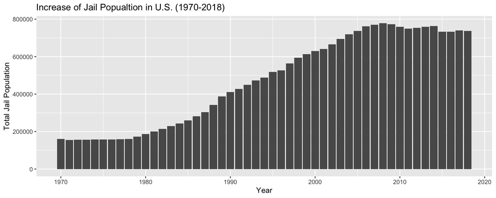

Increase of Jail Population in U.S. - a bar chart showing the trend of the total incarcerated population in the U.S. from 1970 to 2018.

## Growth of the Prison Population by State

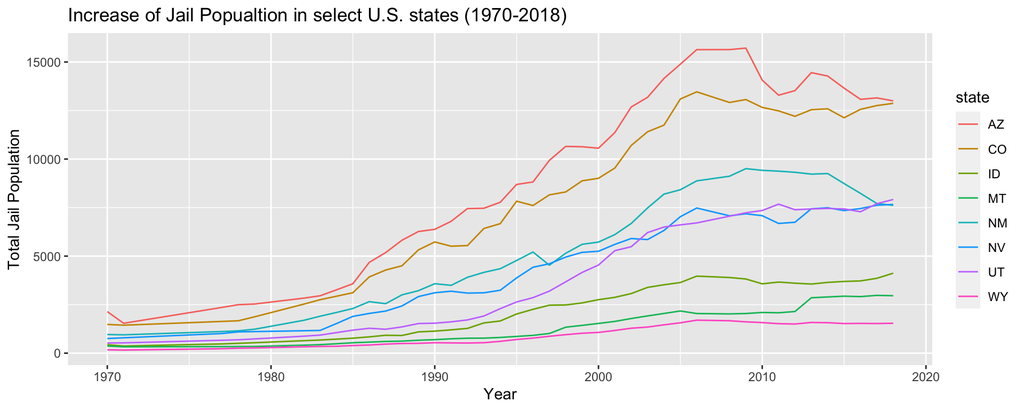

Increase of Jail Population in U.S. States - a line chart showing the trend of the total incarcerated population in U.S. states from 1970 to 2018. States to be displayed are specified in function call.

## Comparing the Percentages of the Black Population in County and Jail

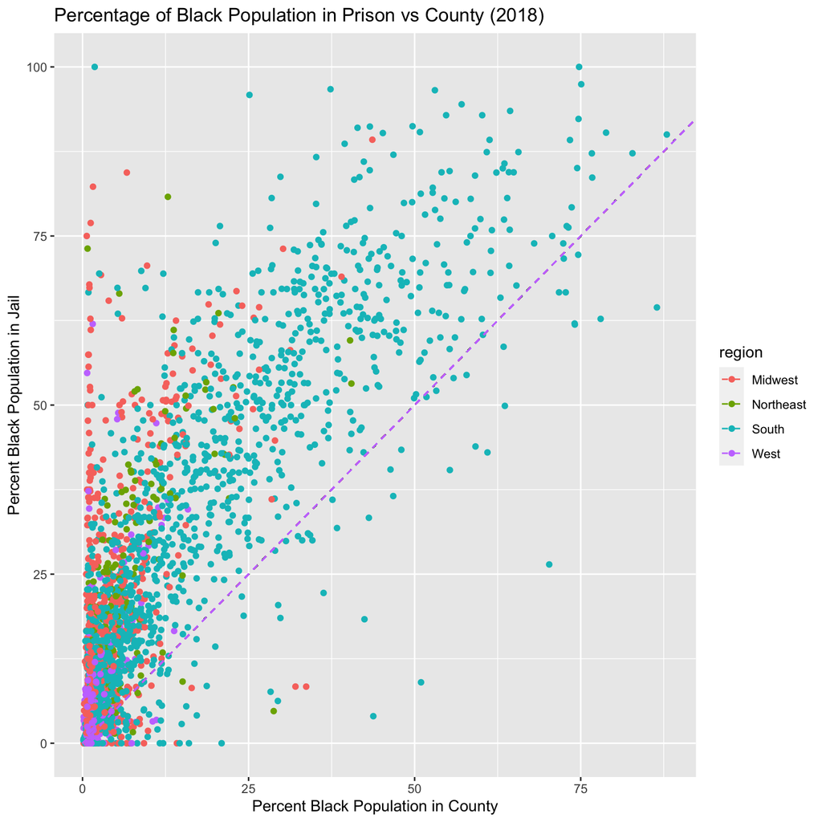

Percentage of the Black Population in County and Jail - a scatter plot showing the percentage of the black population in each county and its jails (2018).

The graph shows a scatter plot of the percentage of the black population in each county and its jails from 2018. Each dot represents a county in the U.S. The dots are color-coded by region. The line y=x is plotted for reference. If all of the points were along this line, we would be able to say that there is no correlation between being black and being in jail. However, a majority of the points are above the line, meaning that black people are overrepresented in jails. The problem especially seems to be bad in midwestern states, where low county populations of black people are juxtaposed by high jail populations of black people.

## Comparing Majority Demographics in U.S. Counties and their Jails

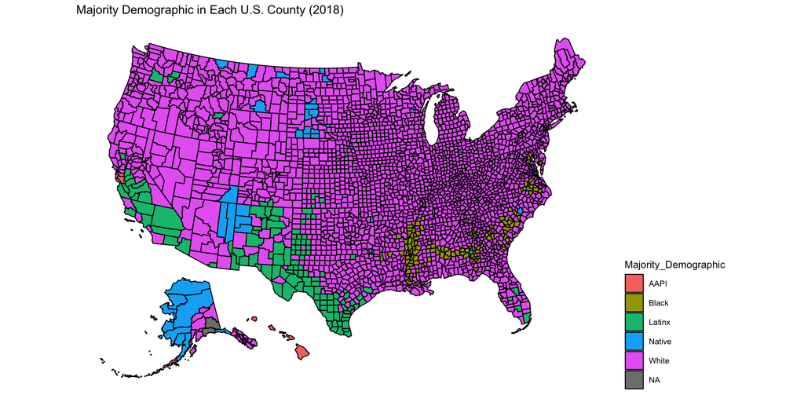

Majority Demographic in U.S. Counties and their Jails - the first plot shows a map of the U.S., each county color-coded with its majority demographic. The second plot shows the same map, color-coded with each county’s majority jail demographic

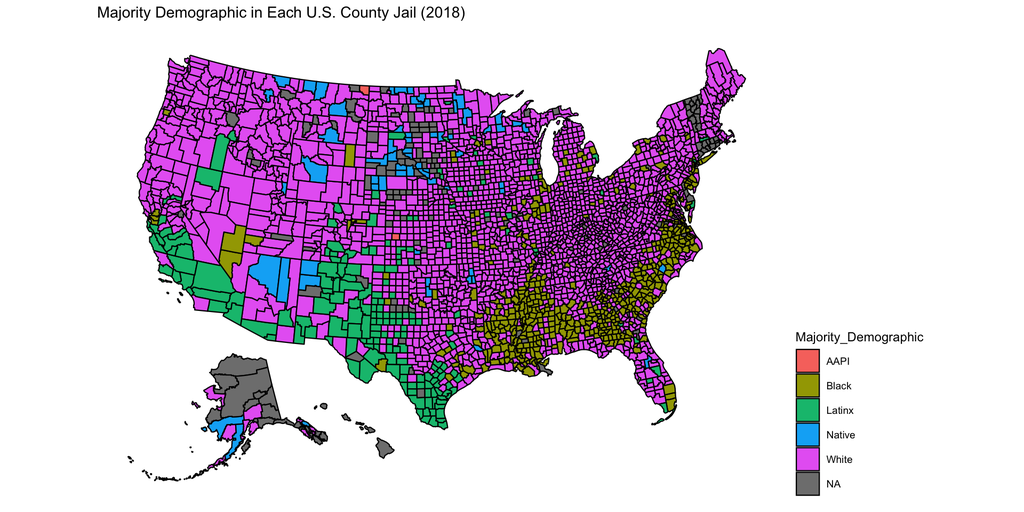

Majority Demographic in U.S. Counties and their Jails - the first plot shows a map of the U.S., each county color-coded with its majority demographic. The second plot shows the same map, color-coded with each county’s majority jail demographic

The two maps show where the majority demographic of a county is misrepresented in its jails. Namely, large swaths of counties in the southeast seem to disproportionately jail black people. The same holds true for latinx people in the southwest. In general, it seems rare for white people to represent a majority in jails where they are not the majority in the county population, while it is more common for black and latinx people to represent a jailed majority in counties where they are a minority.